# Recommendation System Project - Warren Camp

### Recommendation System Project - Warren Camp

Problem Statement - Build your own recommendation system for products on an e-commerce website like Amazon.com.

Dataset columns - first three columns are userId, productId, and ratings and the fourth column is timestamp. You can discard the timestamp column as in this case you may not need to use it.

Source - Amazon Reviews data (http://jmcauley.ucsd.edu/data/amazon/). The repository has several datasets. For this case study, we are using the Electronics dataset.

Please do the analysis based on steps (1 to 8) as given below -

Steps -

1. Read and explore the given dataset. (Rename column/add headers, plot histograms, find data characteristics) - 5
2. Take a subset of the dataset to make it less sparse/ denser. (For example, keep the users only who has given 50 or more number of ratings.) - 10
3. Split the data randomly into train and test dataset. (For example, split it in 70/30 ratio)
4. Build Popularity Recommender model. - 10
5. Build Collaborative Filtering model. - 10
6. Evaluate both the models. (Once the model is trained on the training data, it can be used to compute the error (RMSE) on predictions made on the test data.) - 10
7. Get top - K (K = 5) recommendations. Since our goal is to recommend new products to each user based on his/her habits, we will recommend 5 new products. - 5
8. Summarize your insights. - 10

### Libraries

```python
import numpy as np
import pandas as pd
import math
import json
import time
import matplotlib.pyplot as plt
import seaborn as sns
from sklearn.model_selection import train_test_split
from surprise import SVD
import scipy.sparse
from scipy.sparse import csr_matrix
%matplotlib inline
```

### Step 1. Read and explore the dataset. ( Rename column, plot histograms, find data characteristics)

```python
#Import the data set
df = pd.read_csv('ratings_Electronics.csv', header=None)
print(df.shape)
print(df.head())
print(df.info())
```

```
(7824482, 4)
                0           1    2           3
0   AKM1MP6P0OYPR  0132793040  5.0  1365811200
1  A2CX7LUOHB2NDG  0321732944  5.0  1341100800
2  A2NWSAGRHCP8N5  0439886341  1.0  1367193600
3  A2WNBOD3WNDNKT  0439886341  3.0  1374451200
4  A1GI0U4ZRJA8WN  0439886341  1.0  1334707200
<class 'pandas.core.frame.DataFrame'>
RangeIndex: 7824482 entries, 0 to 7824481
Data columns (total 4 columns):
 #   Column  Dtype
---  ------  -----
 0   0       object
 1   1       object
 2   2       float64
 3   3       int64
dtypes: float64(1), int64(1), object(2)
memory usage: 238.8+ MB
None
```

Observations: 4 columns and 7,824,482 records

```python
# Name the columns userId, productId, ratings and the fourth column is timestamp
df.columns = ['userID', 'productID', 'ratings', 'timestamp']
# discard the timestamp column
df = df.drop('timestamp', axis=1)
print(df.shape)
print(df.info())
print(df.head())
```

```
(7824482, 3)
<class 'pandas.core.frame.DataFrame'>
RangeIndex: 7824482 entries, 0 to 7824481
Data columns (total 3 columns):
 #   Column     Dtype
---  ------     -----
 0   userID     object
 1   productID  object
 2   ratings    float64
dtypes: float64(1), object(2)
memory usage: 179.1+ MB
None
           userID   productID  ratings
0   AKM1MP6P0OYPR  0132793040      5.0
1  A2CX7LUOHB2NDG  0321732944      5.0
2  A2NWSAGRHCP8N5  0439886341      1.0
3  A2WNBOD3WNDNKT  0439886341      3.0
4  A1GI0U4ZRJA8WN  0439886341      1.0
```

```python
# Check for missing values present
print('Number of missing values across columns-\n', df.isnull().sum())
```

```
Number of missing values across columns-
 userID       0
productID    0
ratings      0
dtype: int64
```

Observations: no missing values

```python
# Summary statistics of 'rating' variable
df[['ratings']].describe().transpose()
```

|  | count | mean | std | min | 25% | 50% | 75% | max |
| --- | --- | --- | --- | --- | --- | --- | --- | --- |
| ratings | 7824482.0 | 4.012337 | 1.38091 | 1.0 | 3.0 | 5.0 | 5.0 | 5.0 |

Observation: minimum rating is 1, the maximum is 5, and the mean is 4.01, the rating scal is 1 - 5

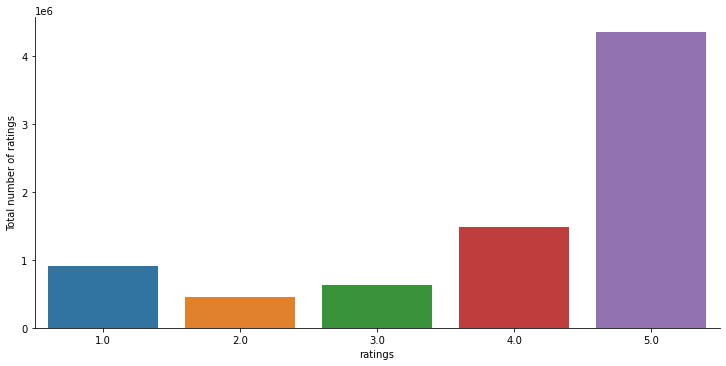

```python
# plot histograms of ratings
g = sns.catplot(x='ratings', data=df, aspect=2.0,kind='count')
g.set_ylabels('Total number of ratings')
```

Observation: Most of the ratings are skewewd towards the high end of the range, 5s and 4s.

```python
# Some find data characteristics include
print('Number of unique USERS: ', df['userID'].nunique())
print('Number of unique Products: ', df['productID'].nunique())
```

```
Number of unique USERS:  4201696
Number of unique Products:  476002
```

Observation: rating range is 1 - 5, number of users is 4,201,696, number of products is 476,002

### Step 2. Take a subset of the dataset to make it less sparse/ denser. (For example, keep the users only who has given 50 or more number of ratings.)

```python
# Top 25 users based on rating
most_rated_users = df.groupby('userID').size().sort_values(ascending=False)[:25]
print(most_rated_users)
```

```
userID
A5JLAU2ARJ0BO     520
ADLVFFE4VBT8      501
A3OXHLG6DIBRW8    498
A6FIAB28IS79      431
A680RUE1FDO8B     406
A1ODOGXEYECQQ8    380
A36K2N527TXXJN    314
A2AY4YUOX2N1BQ    311
AWPODHOB4GFWL     308
A25C2M3QF9G7OQ    296
ARBKYIVNYWK3C     296
A22CW0ZHY3NJH8    292
A3EXWV8FNSSFL6    282
A38RMU1Y5TDP9     282
A3LGT6UZL99IW1    279
A2NOW4U7W3F7RI    277
A23GFTVIETX7DS    270
A3PD8JD9L4WEII    266
A17BUUBOU0598B    261
A3AYSYSLHU26U9    257
A2XRMQA6PJ5ZJ8    253
A231WM2Z2JL0U3    252
A12DQZKRKTNF5E    252
A1UQBFCERIP7VJ    247
AGVWTYW0ULXHT     244
dtype: int64
```

```python
# Select those users who have rated 50  or more products
counts = df['userID'].value_counts()
df_50 = df[df['userID'].isin(counts[counts >= 50].index)]
print(df_50.shape)
```

```
(125871, 3)
```

```python
# Disply the results from the selection process
print('Number of records whose users have rated 50 or more products: ', len(df_50))
print('Number of unique Users: ', df_50['userID'].nunique())
print('Number of unique Products: ', df_50['productID'].nunique())
```

```
Number of records whose users have rated 50 or more products:  125871
Number of unique Users:  1540
Number of unique Products:  48190
```

Observation: We have reduced the number of records from 7,824,482 to 125,871

### Step 3. Split the data randomly into train and test dataset. (For example, split it in 70/30 ratio)

```python
#Split the training and test data in the ratio 70:30
train_data, test_data = train_test_split(df_50, test_size = 0.3, train_size=0.7, random_state=7)
```

### Step 4. Build Popularity Recommender model.

```python
#Count of user_id for each unique product as recommendation score
train_data_grouped = train_data.groupby('productID').agg({'userID': 'count'}).reset_index()
train_data_grouped.rename(columns = {'userID': 'score'},inplace=True)
train_data_grouped.head()
```

|  | productID | score |
| --- | --- | --- |
| 0 | 0594451647 | 1 |
| 1 | 0594481813 | 1 |
| 2 | 0970407998 | 2 |
| 3 | 0972683275 | 4 |
| 4 | 1400501466 | 6 |

```python
#Sort the products on recommendation score
train_data_sort = train_data_grouped.sort_values(['score', 'productID'], ascending = [0,1])
#Generate a recommendation rank based upon score
train_data_sort['Rank'] = train_data_sort['score'].rank(ascending=0, method='first')
#Get the top 5 recommendations
popularity_recommendations = train_data_sort.head(5)
popularity_recommendations
```

|  | productID | score | Rank |
| --- | --- | --- | --- |
| 30877 | B0088CJT4U | 146 | 1.0 |
| 19628 | B003ES5ZUU | 128 | 2.0 |
| 30281 | B007WTAJTO | 114 | 3.0 |
| 8677 | B000N99BBC | 107 | 4.0 |
| 31132 | B008DWCRQW | 105 | 5.0 |

```python
# Get recommendation for userID = 25, 55, 195
popularity_recommendations.loc[:, 'userID'] = 25
cols = popularity_recommendations.columns.tolist()
popularity_recommendations = popularity_recommendations[cols]
popularity_recommendations
```

|  | productID | score | Rank | userID |
| --- | --- | --- | --- | --- |
| 30877 | B0088CJT4U | 146 | 1.0 | 25 |
| 19628 | B003ES5ZUU | 128 | 2.0 | 25 |
| 30281 | B007WTAJTO | 114 | 3.0 | 25 |
| 8677 | B000N99BBC | 107 | 4.0 | 25 |
| 31132 | B008DWCRQW | 105 | 5.0 | 25 |

```python
popularity_recommendations.loc[:, 'userID'] = 55
cols = popularity_recommendations.columns.tolist()
popularity_recommendations = popularity_recommendations[cols]
popularity_recommendations
```

|  | productID | score | Rank | userID |
| --- | --- | --- | --- | --- |
| 30877 | B0088CJT4U | 146 | 1.0 | 55 |
| 19628 | B003ES5ZUU | 128 | 2.0 | 55 |
| 30281 | B007WTAJTO | 114 | 3.0 | 55 |
| 8677 | B000N99BBC | 107 | 4.0 | 55 |
| 31132 | B008DWCRQW | 105 | 5.0 | 55 |

```python
popularity_recommendations.loc[:, 'userID'] = 195
cols = popularity_recommendations.columns.tolist()
popularity_recommendations = popularity_recommendations[cols]
popularity_recommendations
```

|  | productID | score | Rank | userID |
| --- | --- | --- | --- | --- |
| 30877 | B0088CJT4U | 146 | 1.0 | 195 |
| 19628 | B003ES5ZUU | 128 | 2.0 | 195 |
| 30281 | B007WTAJTO | 114 | 3.0 | 195 |
| 8677 | B000N99BBC | 107 | 4.0 | 195 |
| 31132 | B008DWCRQW | 105 | 5.0 | 195 |

### Step 5. Build Collaborative Filtering model.

#### Model-based Collaborative Filtering: Singular Value Decomposition

```python
df_CF = pd.concat([train_data, test_data]).reset_index()
df_CF.tail()
```

|  | index | userID | productID | ratings |
| --- | --- | --- | --- | --- |
| 125866 | 5082378 | AUITG1DJ3QUGK | B005MECHLY | 5.0 |
| 125867 | 2247232 | A2YW6XOID7GV6G | B001QVHO38 | 4.0 |
| 125868 | 5001842 | A1PM7HH4F77NEH | B005IDTH76 | 3.0 |
| 125869 | 6783658 | A17UNMURMLX0ZE | B009YQ8BTI | 5.0 |
| 125870 | 7756956 | AOEDWQLH2WKKW | B00HMREOLK | 3.0 |

```python
#User-based Collaborative Filtering
# Matrix with row per 'user' and column per 'item'
pivot_df = df_CF.pivot(index = 'userID', columns ='productID', values = 'ratings').fillna(0)
print(pivot_df.shape)
pivot_df.head()
```

```
(1540, 48190)
```

| productID userID | 0594451647 | 0594481813 | 0970407998 | 0972683275 | 1400501466 | 1400501520 | 1400501776 | 1400532620 | 1400532655 | 140053271X | ... | B00L5YZCCG | B00L8I6SFY | B00L8QCVL6 | B00LA6T0LS | B00LBZ1Z7K | B00LED02VY | B00LGN7Y3G | B00LGQ6HL8 | B00LI4ZZO8 | B00LKG1MC8 |
| --- | --- | --- | --- | --- | --- | --- | --- | --- | --- | --- | --- | --- | --- | --- | --- | --- | --- | --- | --- | --- | --- |
| A100UD67AHFODS | 0.0 | 0.0 | 0.0 | 0.0 | 0.0 | 0.0 | 0.0 | 0.0 | 0.0 | 0.0 | ... | 0.0 | 0.0 | 0.0 | 0.0 | 0.0 | 0.0 | 0.0 | 0.0 | 0.0 | 0.0 |
| A100WO06OQR8BQ | 0.0 | 0.0 | 0.0 | 0.0 | 0.0 | 0.0 | 0.0 | 0.0 | 0.0 | 0.0 | ... | 0.0 | 0.0 | 0.0 | 0.0 | 0.0 | 0.0 | 0.0 | 0.0 | 0.0 | 0.0 |
| A105S56ODHGJEK | 0.0 | 0.0 | 0.0 | 0.0 | 0.0 | 0.0 | 0.0 | 0.0 | 0.0 | 0.0 | ... | 0.0 | 0.0 | 0.0 | 0.0 | 0.0 | 0.0 | 0.0 | 0.0 | 0.0 | 0.0 |
| A105TOJ6LTVMBG | 0.0 | 0.0 | 0.0 | 0.0 | 0.0 | 0.0 | 0.0 | 0.0 | 0.0 | 0.0 | ... | 0.0 | 0.0 | 0.0 | 0.0 | 0.0 | 0.0 | 0.0 | 0.0 | 0.0 | 0.0 |
| A10AFVU66A79Y1 | 0.0 | 0.0 | 0.0 | 0.0 | 0.0 | 0.0 | 0.0 | 0.0 | 0.0 | 0.0 | ... | 0.0 | 0.0 | 0.0 | 0.0 | 0.0 | 0.0 | 0.0 | 0.0 | 0.0 | 0.0 |

5 rows × 48190 columns

```python
pivot_df['user_index'] = np.arange(0, pivot_df.shape[0], 1)
pivot_df.head()
```

| productID userID | 0594451647 | 0594481813 | 0970407998 | 0972683275 | 1400501466 | 1400501520 | 1400501776 | 1400532620 | 1400532655 | 140053271X | ... | B00L8I6SFY | B00L8QCVL6 | B00LA6T0LS | B00LBZ1Z7K | B00LED02VY | B00LGN7Y3G | B00LGQ6HL8 | B00LI4ZZO8 | B00LKG1MC8 | user_index |
| --- | --- | --- | --- | --- | --- | --- | --- | --- | --- | --- | --- | --- | --- | --- | --- | --- | --- | --- | --- | --- | --- |
| A100UD67AHFODS | 0.0 | 0.0 | 0.0 | 0.0 | 0.0 | 0.0 | 0.0 | 0.0 | 0.0 | 0.0 | ... | 0.0 | 0.0 | 0.0 | 0.0 | 0.0 | 0.0 | 0.0 | 0.0 | 0.0 | 0 |
| A100WO06OQR8BQ | 0.0 | 0.0 | 0.0 | 0.0 | 0.0 | 0.0 | 0.0 | 0.0 | 0.0 | 0.0 | ... | 0.0 | 0.0 | 0.0 | 0.0 | 0.0 | 0.0 | 0.0 | 0.0 | 0.0 | 1 |
| A105S56ODHGJEK | 0.0 | 0.0 | 0.0 | 0.0 | 0.0 | 0.0 | 0.0 | 0.0 | 0.0 | 0.0 | ... | 0.0 | 0.0 | 0.0 | 0.0 | 0.0 | 0.0 | 0.0 | 0.0 | 0.0 | 2 |
| A105TOJ6LTVMBG | 0.0 | 0.0 | 0.0 | 0.0 | 0.0 | 0.0 | 0.0 | 0.0 | 0.0 | 0.0 | ... | 0.0 | 0.0 | 0.0 | 0.0 | 0.0 | 0.0 | 0.0 | 0.0 | 0.0 | 3 |
| A10AFVU66A79Y1 | 0.0 | 0.0 | 0.0 | 0.0 | 0.0 | 0.0 | 0.0 | 0.0 | 0.0 | 0.0 | ... | 0.0 | 0.0 | 0.0 | 0.0 | 0.0 | 0.0 | 0.0 | 0.0 | 0.0 | 4 |

5 rows × 48191 columns

```python
pivot_df.set_index(['user_index'], inplace=True)

# Actual ratings given by users
pivot_df.head()
```

| productID user_index | 0594451647 | 0594481813 | 0970407998 | 0972683275 | 1400501466 | 1400501520 | 1400501776 | 1400532620 | 1400532655 | 140053271X | ... | B00L5YZCCG | B00L8I6SFY | B00L8QCVL6 | B00LA6T0LS | B00LBZ1Z7K | B00LED02VY | B00LGN7Y3G | B00LGQ6HL8 | B00LI4ZZO8 | B00LKG1MC8 |
| --- | --- | --- | --- | --- | --- | --- | --- | --- | --- | --- | --- | --- | --- | --- | --- | --- | --- | --- | --- | --- | --- |
| 0 | 0.0 | 0.0 | 0.0 | 0.0 | 0.0 | 0.0 | 0.0 | 0.0 | 0.0 | 0.0 | ... | 0.0 | 0.0 | 0.0 | 0.0 | 0.0 | 0.0 | 0.0 | 0.0 | 0.0 | 0.0 |
| 1 | 0.0 | 0.0 | 0.0 | 0.0 | 0.0 | 0.0 | 0.0 | 0.0 | 0.0 | 0.0 | ... | 0.0 | 0.0 | 0.0 | 0.0 | 0.0 | 0.0 | 0.0 | 0.0 | 0.0 | 0.0 |
| 2 | 0.0 | 0.0 | 0.0 | 0.0 | 0.0 | 0.0 | 0.0 | 0.0 | 0.0 | 0.0 | ... | 0.0 | 0.0 | 0.0 | 0.0 | 0.0 | 0.0 | 0.0 | 0.0 | 0.0 | 0.0 |
| 3 | 0.0 | 0.0 | 0.0 | 0.0 | 0.0 | 0.0 | 0.0 | 0.0 | 0.0 | 0.0 | ... | 0.0 | 0.0 | 0.0 | 0.0 | 0.0 | 0.0 | 0.0 | 0.0 | 0.0 | 0.0 |
| 4 | 0.0 | 0.0 | 0.0 | 0.0 | 0.0 | 0.0 | 0.0 | 0.0 | 0.0 | 0.0 | ... | 0.0 | 0.0 | 0.0 | 0.0 | 0.0 | 0.0 | 0.0 | 0.0 | 0.0 | 0.0 |

5 rows × 48190 columns

### SVD method

#### SVD is best to apply on a large sparse matrix

```python
from scipy.sparse.linalg import svds
# Singular Value Decomposition
U, sigma, Vt = svds(pivot_df, k = 50)
# Construct diagonal array in SVD
sigma = np.diag(sigma)
```

### Note that for sparse matrices, you can use the sparse.linalg.svds() function to perform the decomposition.

SVD is useful in many tasks, such as data compression, noise reduction similar to Principal Component Analysis and Latent Semantic Indexing (LSI), used in document retrieval and word similarity in Text mining

```python
all_user_predicted_ratings = np.dot(np.dot(U, sigma), Vt)

# Predicted ratings
preds_df = pd.DataFrame(all_user_predicted_ratings, columns = pivot_df.columns)
preds_df.head()
```

| productID | 0594451647 | 0594481813 | 0970407998 | 0972683275 | 1400501466 | 1400501520 | 1400501776 | 1400532620 | 1400532655 | 140053271X | ... | B00L5YZCCG | B00L8I6SFY | B00L8QCVL6 | B00LA6T0LS | B00LBZ1Z7K | B00LED02VY | B00LGN7Y3G | B00LGQ6HL8 | B00LI4ZZO8 | B00LKG1MC8 |
| --- | --- | --- | --- | --- | --- | --- | --- | --- | --- | --- | --- | --- | --- | --- | --- | --- | --- | --- | --- | --- | --- |
| 0 | 0.005086 | 0.002178 | 0.003668 | -0.040843 | 0.009640 | 0.006808 | 0.020659 | 0.000649 | 0.020331 | 0.005633 | ... | 0.000238 | -0.061477 | 0.001214 | -0.123433 | 0.028490 | 0.016109 | 0.002855 | -0.174568 | 0.011367 | -0.012997 |
| 1 | 0.002286 | -0.010898 | -0.000724 | 0.130259 | 0.007506 | -0.003350 | 0.063711 | -0.000674 | 0.016111 | -0.002433 | ... | -0.000038 | 0.013766 | 0.001473 | 0.025588 | -0.042103 | 0.004251 | 0.002177 | -0.024362 | -0.014765 | 0.038570 |
| 2 | -0.001655 | -0.002675 | -0.007355 | 0.007264 | 0.005152 | -0.003986 | -0.003480 | 0.006961 | -0.006606 | -0.002719 | ... | -0.001708 | -0.051040 | 0.000325 | -0.054867 | 0.017870 | -0.004996 | -0.002426 | 0.083928 | -0.112205 | 0.005964 |
| 3 | 0.001856 | 0.011019 | -0.005910 | -0.014134 | 0.000179 | 0.001877 | -0.005391 | -0.001709 | 0.004968 | 0.001402 | ... | 0.000582 | -0.009326 | -0.000465 | -0.048315 | 0.023302 | 0.006790 | 0.003380 | 0.005460 | -0.015263 | -0.025996 |
| 4 | 0.001115 | -0.002670 | 0.011018 | 0.014434 | 0.010319 | 0.006002 | 0.017151 | 0.003726 | 0.001404 | 0.005645 | ... | 0.000207 | 0.023761 | 0.000747 | -0.019347 | -0.012749 | 0.001026 | 0.001364 | -0.020580 | 0.011828 | 0.012770 |

5 rows × 48190 columns

```python
# Recommend the items with the highest predicted ratings

def recommend_items(userID, pivot_df, preds_df, num_recommendations):

    user_idx = userID-1 # index starts at 0

    # Get and sort the user's ratings
    sorted_user_ratings = pivot_df.iloc[user_idx].sort_values(ascending=False)
    #sorted_user_ratings
    sorted_user_predictions = preds_df.iloc[user_idx].sort_values(ascending=False)
    #sorted_user_predictions

    temp = pd.concat([sorted_user_ratings, sorted_user_predictions], axis=1)
    temp.index.name = 'Recommended Items'
    temp.columns = ['user_ratings', 'user_predictions']

    temp = temp.loc[temp.user_ratings == 0]
    temp = temp.sort_values('user_predictions', ascending=False)
    print('\nBelow are the recommended items for user(user_id = {}):\n'.format(userID))
    print(temp.head(num_recommendations))
```

```python
#Enter 'userID' and 'num_recommendations' for the user #
userID = 25
num_recommendations = 5
recommend_items(userID, pivot_df, preds_df, num_recommendations)
```

```
Below are the recommended items for user(user_id = 25):

                   user_ratings  user_predictions
Recommended Items
B002V88HFE                  0.0          0.658431
B005CT56F8                  0.0          0.627009
B00BQ4F9ZA                  0.0          0.608734
B003ES5ZUU                  0.0          0.573753
B00E3W15P0                  0.0          0.571966
```

```python
#Enter 'userID' and 'num_recommendations' for the user #
userID = 55
num_recommendations = 5
recommend_items(userID, pivot_df, preds_df, num_recommendations)
```

```
Below are the recommended items for user(user_id = 55):

                   user_ratings  user_predictions
Recommended Items
B007WTAJTO                  0.0          0.749329
B003ES5ZUU                  0.0          0.656910
B001TH7GUU                  0.0          0.529127
B002WE6D44                  0.0          0.509846
B000VX6XL6                  0.0          0.495339
```

```python
#Enter 'userID' and 'num_recommendations' for the user #
userID = 195
num_recommendations = 5
recommend_items(userID, pivot_df, preds_df, num_recommendations)
```

```
Below are the recommended items for user(user_id = 195):

                   user_ratings  user_predictions
Recommended Items
B004CLYEFK                  0.0          1.337240
B0079UAT0A                  0.0          1.130363
B00834SJSK                  0.0          1.094901
B0034CL2ZI                  0.0          0.938819
B00ARB5FLQ                  0.0          0.784889
```

#### Evaluation of Model-based Collaborative Filtering (SVD)

```python
# Actual ratings given by users
pivot_df.head()
```

| productID user_index | 0594451647 | 0594481813 | 0970407998 | 0972683275 | 1400501466 | 1400501520 | 1400501776 | 1400532620 | 1400532655 | 140053271X | ... | B00L5YZCCG | B00L8I6SFY | B00L8QCVL6 | B00LA6T0LS | B00LBZ1Z7K | B00LED02VY | B00LGN7Y3G | B00LGQ6HL8 | B00LI4ZZO8 | B00LKG1MC8 |
| --- | --- | --- | --- | --- | --- | --- | --- | --- | --- | --- | --- | --- | --- | --- | --- | --- | --- | --- | --- | --- | --- |
| 0 | 0.0 | 0.0 | 0.0 | 0.0 | 0.0 | 0.0 | 0.0 | 0.0 | 0.0 | 0.0 | ... | 0.0 | 0.0 | 0.0 | 0.0 | 0.0 | 0.0 | 0.0 | 0.0 | 0.0 | 0.0 |
| 1 | 0.0 | 0.0 | 0.0 | 0.0 | 0.0 | 0.0 | 0.0 | 0.0 | 0.0 | 0.0 | ... | 0.0 | 0.0 | 0.0 | 0.0 | 0.0 | 0.0 | 0.0 | 0.0 | 0.0 | 0.0 |
| 2 | 0.0 | 0.0 | 0.0 | 0.0 | 0.0 | 0.0 | 0.0 | 0.0 | 0.0 | 0.0 | ... | 0.0 | 0.0 | 0.0 | 0.0 | 0.0 | 0.0 | 0.0 | 0.0 | 0.0 | 0.0 |
| 3 | 0.0 | 0.0 | 0.0 | 0.0 | 0.0 | 0.0 | 0.0 | 0.0 | 0.0 | 0.0 | ... | 0.0 | 0.0 | 0.0 | 0.0 | 0.0 | 0.0 | 0.0 | 0.0 | 0.0 | 0.0 |
| 4 | 0.0 | 0.0 | 0.0 | 0.0 | 0.0 | 0.0 | 0.0 | 0.0 | 0.0 | 0.0 | ... | 0.0 | 0.0 | 0.0 | 0.0 | 0.0 | 0.0 | 0.0 | 0.0 | 0.0 | 0.0 |

5 rows × 48190 columns

```python
# Average ACTUAL rating for each item
pivot_df.mean().head()
```

```
productID
0594451647    0.003247
0594481813    0.001948
0970407998    0.003247
0972683275    0.012338
1400501466    0.012987
dtype: float64
```

```python
# Predicted ratings
preds_df.head()
```

| productID | 0594451647 | 0594481813 | 0970407998 | 0972683275 | 1400501466 | 1400501520 | 1400501776 | 1400532620 | 1400532655 | 140053271X | ... | B00L5YZCCG | B00L8I6SFY | B00L8QCVL6 | B00LA6T0LS | B00LBZ1Z7K | B00LED02VY | B00LGN7Y3G | B00LGQ6HL8 | B00LI4ZZO8 | B00LKG1MC8 |
| --- | --- | --- | --- | --- | --- | --- | --- | --- | --- | --- | --- | --- | --- | --- | --- | --- | --- | --- | --- | --- | --- |
| 0 | 0.005086 | 0.002178 | 0.003668 | -0.040843 | 0.009640 | 0.006808 | 0.020659 | 0.000649 | 0.020331 | 0.005633 | ... | 0.000238 | -0.061477 | 0.001214 | -0.123433 | 0.028490 | 0.016109 | 0.002855 | -0.174568 | 0.011367 | -0.012997 |
| 1 | 0.002286 | -0.010898 | -0.000724 | 0.130259 | 0.007506 | -0.003350 | 0.063711 | -0.000674 | 0.016111 | -0.002433 | ... | -0.000038 | 0.013766 | 0.001473 | 0.025588 | -0.042103 | 0.004251 | 0.002177 | -0.024362 | -0.014765 | 0.038570 |
| 2 | -0.001655 | -0.002675 | -0.007355 | 0.007264 | 0.005152 | -0.003986 | -0.003480 | 0.006961 | -0.006606 | -0.002719 | ... | -0.001708 | -0.051040 | 0.000325 | -0.054867 | 0.017870 | -0.004996 | -0.002426 | 0.083928 | -0.112205 | 0.005964 |
| 3 | 0.001856 | 0.011019 | -0.005910 | -0.014134 | 0.000179 | 0.001877 | -0.005391 | -0.001709 | 0.004968 | 0.001402 | ... | 0.000582 | -0.009326 | -0.000465 | -0.048315 | 0.023302 | 0.006790 | 0.003380 | 0.005460 | -0.015263 | -0.025996 |
| 4 | 0.001115 | -0.002670 | 0.011018 | 0.014434 | 0.010319 | 0.006002 | 0.017151 | 0.003726 | 0.001404 | 0.005645 | ... | 0.000207 | 0.023761 | 0.000747 | -0.019347 | -0.012749 | 0.001026 | 0.001364 | -0.020580 | 0.011828 | 0.012770 |

5 rows × 48190 columns

```python
# Average PREDICTED rating for each item
preds_df.mean().head()
```

```
productID
0594451647    0.001953
0594481813    0.002875
0970407998    0.003355
0972683275    0.010343
1400501466    0.004871
dtype: float64
```

```python
rmse_df = pd.concat([pivot_df.mean(), preds_df.mean()], axis=1)
rmse_df.columns = ['Avg_actual_ratings', 'Avg_predicted_ratings']
print(rmse_df.shape)
rmse_df['item_index'] = np.arange(0, rmse_df.shape[0], 1)
rmse_df.head()
```

```
(48190, 2)
```

| productID | Avg_actual_ratings | Avg_predicted_ratings | item_index |
| --- | --- | --- | --- |
| 0594451647 | 0.003247 | 0.001953 | 0 |
| 0594481813 | 0.001948 | 0.002875 | 1 |
| 0970407998 | 0.003247 | 0.003355 | 2 |
| 0972683275 | 0.012338 | 0.010343 | 3 |
| 1400501466 | 0.012987 | 0.004871 | 4 |

```python
RMSE = round((((rmse_df.Avg_actual_ratings - rmse_df.Avg_predicted_ratings) ** 2).mean() ** 0.5), 5)
print('\nRMSE SVD Model = {} \n'.format(RMSE))
```

```
RMSE SVD Model = 0.00275
```

### Step 7. Get top - K (K = 5) recommendations. Since our goal is to recommend new products to each user based on his/her habits, we will recommend 5 new products.

```python
# Enter 'userID' and 'num_recommendations' for the user #
userID = 25
num_recommendations = 5
recommend_items(userID, pivot_df, preds_df, num_recommendations)
```

```
Below are the recommended items for user(user_id = 25):

                   user_ratings  user_predictions
Recommended Items
B002V88HFE                  0.0          0.658431
B005CT56F8                  0.0          0.627009
B00BQ4F9ZA                  0.0          0.608734
B003ES5ZUU                  0.0          0.573753
B00E3W15P0                  0.0          0.571966
```

```python
# Enter 'userID' and 'num_recommendations' for the user #
userID = 55
num_recommendations = 5
recommend_items(userID, pivot_df, preds_df, num_recommendations)
```

```
Below are the recommended items for user(user_id = 55):

                   user_ratings  user_predictions
Recommended Items
B007WTAJTO                  0.0          0.749329
B003ES5ZUU                  0.0          0.656910
B001TH7GUU                  0.0          0.529127
B002WE6D44                  0.0          0.509846
B000VX6XL6                  0.0          0.495339
```

```python
# Enter 'userID' and 'num_recommendations' for the user #
userID = 195
num_recommendations = 5
recommend_items(userID, pivot_df, preds_df, num_recommendations)
```

```
Below are the recommended items for user(user_id = 195):

                   user_ratings  user_predictions
Recommended Items
B004CLYEFK                  0.0          1.337240
B0079UAT0A                  0.0          1.130363
B00834SJSK                  0.0          1.094901
B0034CL2ZI                  0.0          0.938819
B00ARB5FLQ                  0.0          0.784889
```

### Step 8. Summarise your insights.

Popularity Based recommendation systems are systems that do recommendation based on popularity (frequency counts). These recommendations may not be suitable for the user. The Popularity based model recommended the same set of 5 products for all three users (25, 55, 195). This model is useful when there is no prior user preference history (personalized information), therefore the most popular products are the best recommendation.